# Filtering trajectories

```r
library(move2)
library(dplyr)
library(units)
library(sf)
```

Download example data and select columns to reduce printing.

```r
galapagos_albatrosses <- movebank_download_study(2911040,
  attributes = c(
    "ground_speed",
    "heading",
    "height_above_ellipsoid",
    "eobs_temperature",
    "individual_local_identifier"
  )
) %>%
  select_track_data(study_site, weight, animal_life_stage)
```

# Filtering locations

## Omit empty locations

```r
galapagos_albatrosses %>%
  filter(!st_is_empty(.))
```

```
#> A <move2> with `track_id_column` "individual_local_identifier" and `time_column`
#> "timestamp"
#> Containing 28 tracks lasting on average 37.1 days in a
#> Simple feature collection with 16028 features and 6 fields
#> Geometry type: POINT
#> Dimension:     XY
#> Bounding box:  xmin: -91.3732 ymin: -12.79464 xmax: -77.51874 ymax: 0.1821983
#> Geodetic CRS:  WGS 84
#> # A tibble: 16,028 × 7
#>   ground_speed heading height_above_ellipsoid eobs_temperature
#> *        [m/s]     [°]                    [m]             [°C]
#> 1         0.01   21.6                    16.5               12
#> 2         0      95.7                    12.6               19
#> 3         0.11   13.8                    17.4               24
#> 4         0.2     9.83                   24.8               18
#> 5         0.24   37.4                    19                 22
#> # ℹ 16,023 more rows
#> # ℹ 3 more variables: individual_local_identifier <fct>, timestamp <dttm>,
#> #   geometry <POINT [°]>
#> First 5 track features:
#> # A tibble: 28 × 4
#>   study_site       weight animal_life_stage individual_local_identifier
#>   <chr>               [g] <fct>             <fct>
#> 1 Isla de la Plata     22 adult             unbanded-151
#> 2 Isla de la Plata     22 adult             unbanded-153
#> 3 Isla de la Plata     22 adult             unbanded-154
#> 4 Isla de la Plata     22 adult             unbanded-156
#> 5 Isla de la Plata     22 adult             unbanded-159
#> # ℹ 23 more rows
```

## Temporal filtering

First location each 6 hour window

```r
galapagos_albatrosses %>%
  filter(!st_is_empty(.)) %>%
  mt_filter_per_interval(unit = "6 hours")
```

```
#> A <move2> with `track_id_column` "individual_local_identifier" and `time_column`
#> "timestamp"
#> Containing 28 tracks lasting on average 37 days in a
#> Simple feature collection with 4109 features and 6 fields
#> Geometry type: POINT
#> Dimension:     XY
#> Bounding box:  xmin: -91.3296 ymin: -12.79464 xmax: -77.52837 ymax: 0.1814998
#> Geodetic CRS:  WGS 84
#> # A tibble: 4,109 × 7
#>   ground_speed heading height_above_ellipsoid eobs_temperature
#> *        [m/s]     [°]                    [m]             [°C]
#> 1         0.01   21.6                    16.5               12
#> 2         0.2     9.83                   24.8               18
#> 3         0.32  334.                     14.8               15
#> 4         0.08  330.                     10.4               11
#> 5         0.1    10.5                     8.6               12
#> # ℹ 4,104 more rows
#> # ℹ 3 more variables: individual_local_identifier <fct>, timestamp <dttm>,
#> #   geometry <POINT [°]>
#> First 5 track features:
#> # A tibble: 28 × 4
#>   study_site       weight animal_life_stage individual_local_identifier
#>   <chr>               [g] <fct>             <fct>
#> 1 Isla de la Plata     22 adult             unbanded-151
#> 2 Isla de la Plata     22 adult             unbanded-153
#> 3 Isla de la Plata     22 adult             unbanded-154
#> 4 Isla de la Plata     22 adult             unbanded-156
#> 5 Isla de la Plata     22 adult             unbanded-159
#> # ℹ 23 more rows
```

Random location each day

```r
galapagos_albatrosses %>%
  filter(!st_is_empty(.)) %>%
  mt_filter_per_interval(criterion = "random", unit = "days")
```

```
#> A <move2> with `track_id_column` "individual_local_identifier" and `time_column`
#> "timestamp"
#> Containing 28 tracks lasting on average 36.7 days in a
#> Simple feature collection with 1057 features and 6 fields
#> Geometry type: POINT
#> Dimension:     XY
#> Bounding box:  xmin: -91.23807 ymin: -12.78474 xmax: -77.56545 ymax: -0.1689596
#> Geodetic CRS:  WGS 84
#> # A tibble: 1,057 × 7
#>   ground_speed heading height_above_ellipsoid eobs_temperature
#> *        [m/s]     [°]                    [m]             [°C]
#> 1         0.01    21.6                   16.5               12
#> 2         0.11    36.0                   13                 21
#> 3         0.56   287.                    -0.4               17
#> 4         0.83   328.                    -3.9               11
#> 5        10.4    102.                    11.3                9
#> # ℹ 1,052 more rows
#> # ℹ 3 more variables: individual_local_identifier <fct>, timestamp <dttm>,
#> #   geometry <POINT [°]>
#> First 5 track features:
#> # A tibble: 28 × 4
#>   study_site       weight animal_life_stage individual_local_identifier
#>   <chr>               [g] <fct>             <fct>
#> 1 Isla de la Plata     22 adult             unbanded-151
#> 2 Isla de la Plata     22 adult             unbanded-153
#> 3 Isla de la Plata     22 adult             unbanded-154
#> 4 Isla de la Plata     22 adult             unbanded-156
#> 5 Isla de la Plata     22 adult             unbanded-159
#> # ℹ 23 more rows
```

# Finding and filtering duplicated records

When dealing with trajectories frequently duplicated records do occur. There are many reasons these can appear ranging from the way in which data is recorded to duplicated data transmissions and uploads. These data are often stored, but for analysis they need to be removed. A simple definition of a duplicate record would be an observation at exactly the same time of the same individual. However many tracking devices record additional information such as acceleration. These records frequently have the same time as location records meaning not all records with duplicated timestamps can directly be deleted.

Duplicated records can be found in the following way:

```r
galapagos_albatrosses %>%
  group_by(mt_time(), mt_track_id()) %>%
  filter(n() != 1) %>%
  arrange(mt_time())
```

```
#> A <move2> with `track_id_column` "individual_local_identifier" and `time_column`
#> "timestamp"
#> Containing 28 tracks lasting on average 36.7 days in a
#> Simple feature collection with 8092 features and 8 fields (with 4066 geometries empty)
#> Geometry type: POINT
#> Dimension:     XY
#> Bounding box:  xmin: -91.24518 ymin: -12.79464 xmax: -77.51874 ymax: 0.1821983
#> Geodetic CRS:  WGS 84
#> # A tibble: 8,092 × 9
#> # Groups:   mt_time(), mt_track_id() [4,046]
#>   ground_speed heading height_above_ellipsoid eobs_temperature
#>          [m/s]     [°]                    [m]             [°C]
#> 1         0.3     14.4                    7.9               27
#> 2        NA       NA                     NA                 NA
#> 3         0.55   330.                     1.6               24
#> 4        NA       NA                     NA                 NA
#> 5         0.15    53.1                   11.4               27
#> # ℹ 8,087 more rows
#> # ℹ 5 more variables: individual_local_identifier <fct>, timestamp <dttm>,
#> #   geometry <POINT [°]>, `mt_time()` <dttm>, `mt_track_id()` <fct>
#> First 5 track features:
#> # A tibble: 28 × 4
#>   study_site       weight animal_life_stage individual_local_identifier
#>   <chr>               [g] <fct>             <fct>
#> 1 Isla de la Plata     22 adult             unbanded-151
#> 2 Isla de la Plata     22 adult             unbanded-153
#> 3 Isla de la Plata     22 adult             unbanded-154
#> 4 Isla de la Plata     22 adult             unbanded-156
#> 5 Isla de la Plata     22 adult             unbanded-159
#> # ℹ 23 more rows
```

If you are only interested in finding duplicated records where there is a location this can as follows (in this case there are none):

```r
galapagos_albatrosses %>%
  filter(!st_is_empty(.)) %>%
  group_by(mt_time(), mt_track_id()) %>%
  filter(n() != 1) %>%
  arrange(mt_time())
```

[output not shown]

The package also has some build in functions for filtering unique records. Several strategies for omitting duplicated records are build in.

First it is possible to omit all records that are a subset of other records, i.e. records that got added later with more information are retained. This happens with some tracking devices if data gets directly downloaded from the tag. As no information is lost this is the default strategy.

```r
simulated_data <- mt_sim_brownian_motion(1:2)[rep(1:4, 2), ]
simulated_data$temperature <- c(1:3, NA, 1:2, 7:8)
simulated_data
```

```
#> A <move2> with `track_id_column` "track" and `time_column` "time"
#> Containing 2 tracks lasting on average 1 secs in a
#> Simple feature collection with 8 features and 3 fields
#> Geometry type: POINT
#> Dimension:     XY
#> Bounding box:  xmin: 0 ymin: -0.2327622 xmax: 2.656222 ymax: 1.092814
#> CRS:           NA
#> First 5 features:
#>     time track                    geometry temperature
#> 1      1     1                 POINT (0 0)           1
#> 2      2     1 POINT (0.946932 -0.2327622)           2
#> 3      1     2                 POINT (0 0)           3
#> 4      2     2   POINT (2.656222 1.092814)          NA
#> 1.1    1     1                 POINT (0 0)           1
#> Track features:
#>   track
#> 1     1
#> 2     2
```

```r
simulated_data %>% mt_filter_unique()
```

[output not shown]

This strategy how ever does not guarantee not duplicates are left, as two records might not be subsets from each other.

An alternative is to take a random record from each set of duplicates, this is not advised for formal analysis but might help for a quick inspection of data. This is also a lot quicker then inspecting subsets. How ever care needs to be taken as the example below, for example, results in empty points being retained at the cost of informative locations.

```r
galapagos_albatrosses %>% mt_filter_unique("sample")
```

```
#> A <move2> with `track_id_column` "individual_local_identifier" and `time_column`
#> "timestamp"
#> Containing 28 tracks lasting on average 37.1 days in a
#> Simple feature collection with 110883 features and 6 fields (with 96829 geometries empty)
#> Geometry type: POINT
#> Dimension:     XY
#> Bounding box:  xmin: -91.3732 ymin: -12.79128 xmax: -77.52837 ymax: 0.1814998
#> Geodetic CRS:  WGS 84
#> # A tibble: 110,883 × 7
#>   ground_speed heading height_above_ellipsoid eobs_temperature
#> *        [m/s]     [°]                    [m]             [°C]
#> 1         0.01   21.6                    16.5               12
#> 2         0      95.7                    12.6               19
#> 3         0.11   13.8                    17.4               24
#> 4         0.2     9.83                   24.8               18
#> 5         0.24   37.4                    19                 22
#> # ℹ 110,878 more rows
#> # ℹ 3 more variables: individual_local_identifier <fct>, timestamp <dttm>,
#> #   geometry <POINT [°]>
#> First 5 track features:
#> # A tibble: 28 × 4
#>   study_site       weight animal_life_stage individual_local_identifier
#>   <chr>               [g] <fct>             <fct>
#> 1 Isla de la Plata     22 adult             unbanded-151
#> 2 Isla de la Plata     22 adult             unbanded-153
#> 3 Isla de la Plata     22 adult             unbanded-154
#> 4 Isla de la Plata     22 adult             unbanded-156
#> 5 Isla de la Plata     22 adult             unbanded-159
#> # ℹ 23 more rows
```

# Filtering tracks

## Tracks with at least `n` locations

```r
galapagos_albatrosses %>%
  group_by(mt_track_id()) %>%
  filter(n() > 500)
```

```
#> A <move2> with `track_id_column` "individual_local_identifier" and `time_column`
#> "timestamp"
#> Containing 20 tracks lasting on average 50.9 days in a
#> Simple feature collection with 112639 features and 7 fields (with 96941 geometries empty)
#> Geometry type: POINT
#> Dimension:     XY
#> Bounding box:  xmin: -91.3732 ymin: -12.79464 xmax: -77.51874 ymax: 0.1821983
#> Geodetic CRS:  WGS 84
#> # A tibble: 112,639 × 8
#> # Groups:   mt_track_id() [20]
#>   ground_speed heading height_above_ellipsoid eobs_temperature
#> *        [m/s]     [°]                    [m]             [°C]
#> 1         0.01   21.6                    16.5               12
#> 2         0      95.7                    12.6               19
#> 3         0.11   13.8                    17.4               24
#> 4         0.2     9.83                   24.8               18
#> 5         0.24   37.4                    19                 22
#> # ℹ 112,634 more rows
#> # ℹ 4 more variables: individual_local_identifier <fct>, timestamp <dttm>,
#> #   geometry <POINT [°]>, `mt_track_id()` <fct>
#> First 5 track features:
#> # A tibble: 20 × 4
#>   study_site       weight animal_life_stage individual_local_identifier
#>   <chr>               [g] <fct>             <fct>
#> 1 Isla de la Plata     22 adult             unbanded-151
#> 2 Isla de la Plata     22 adult             unbanded-153
#> 3 Isla de la Plata     22 adult             unbanded-154
#> 4 Isla de la Plata     22 adult             unbanded-156
#> 5 Isla de la Plata     22 adult             unbanded-159
#> # ℹ 15 more rows
```

## Tracks having a minimal duration

```r
galapagos_albatrosses %>%
  group_by(mt_track_id()) %>%
  filter(as_units(diff(range(mt_time()))) > set_units(1, "week"))
```

```
#> A <move2> with `track_id_column` "individual_local_identifier" and `time_column`
#> "timestamp"
#> Containing 19 tracks lasting on average 53.3 days in a
#> Simple feature collection with 111971 features and 7 fields (with 96369 geometries empty)
#> Geometry type: POINT
#> Dimension:     XY
#> Bounding box:  xmin: -91.3732 ymin: -12.79464 xmax: -77.51874 ymax: 0.1821983
#> Geodetic CRS:  WGS 84
#> # A tibble: 111,971 × 8
#> # Groups:   mt_track_id() [19]
#>   ground_speed heading height_above_ellipsoid eobs_temperature
#> *        [m/s]     [°]                    [m]             [°C]
#> 1         0.01   21.6                    16.5               12
#> 2         0      95.7                    12.6               19
#> 3         0.11   13.8                    17.4               24
#> 4         0.2     9.83                   24.8               18
#> 5         0.24   37.4                    19                 22
#> # ℹ 111,966 more rows
#> # ℹ 4 more variables: individual_local_identifier <fct>, timestamp <dttm>,
#> #   geometry <POINT [°]>, `mt_track_id()` <fct>
#> First 5 track features:
#> # A tibble: 19 × 4
#>   study_site       weight animal_life_stage individual_local_identifier
#>   <chr>               [g] <fct>             <fct>
#> 1 Isla de la Plata     22 adult             unbanded-151
#> 2 Isla de la Plata     22 adult             unbanded-153
#> 3 Isla de la Plata     22 adult             unbanded-154
#> 4 Isla de la Plata     22 adult             unbanded-156
#> 5 Isla de la Plata     22 adult             unbanded-159
#> # ℹ 14 more rows
```

## Tracks that visit foraging area at least once

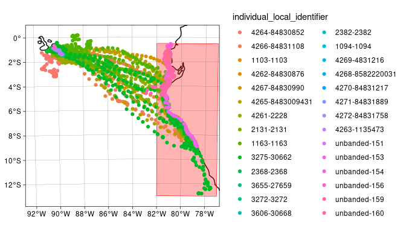

```r
foraging_area <- st_as_sfc(st_bbox(c(
  xmin = -82, xmax = -77,
  ymax = -0.5, ymin = -13
), crs = 4326))
library(ggplot2, quietly = TRUE)
ggplot() +
  geom_sf(data = rnaturalearth::ne_coastline(returnclass = "sf", 50)) +
  theme_linedraw() +
  geom_sf(data = foraging_area, fill = "red", alpha = 0.3, color = "red") +
  geom_sf(
    data = galapagos_albatrosses %>% filter(!st_is_empty(.)),
    aes(color = `individual_local_identifier`)
  ) +
  coord_sf(
    crs = sf::st_crs("+proj=aeqd +lon_0=-83 +lat_0=-6 +units=km"),
    xlim = c(-1000, 600), ylim = c(-800, 700)
  )
```

```r
# Filter to tracks making it at least once to the foraging area
galapagos_albatrosses %>%
  group_by(mt_track_id()) %>%
  filter(any(st_intersects(geometry, foraging_area, sparse = FALSE)))
```

```
#> A <move2> with `track_id_column` "individual_local_identifier" and `time_column`
#> "timestamp"
#> Containing 15 tracks lasting on average 63.9 days in a
#> Simple feature collection with 106151 features and 7 fields (with 91303 geometries empty)
#> Geometry type: POINT
#> Dimension:     XY
#> Bounding box:  xmin: -91.3732 ymin: -12.79464 xmax: -77.51874 ymax: 0.1821983
#> Geodetic CRS:  WGS 84
#> # A tibble: 106,151 × 8
#> # Groups:   mt_track_id() [15]
#>   ground_speed heading height_above_ellipsoid eobs_temperature
#> *        [m/s]     [°]                    [m]             [°C]
#> 1         0.01   21.6                    16.5               12
#> 2         0      95.7                    12.6               19
#> 3         0.11   13.8                    17.4               24
#> 4         0.2     9.83                   24.8               18
#> 5         0.24   37.4                    19                 22
#> # ℹ 106,146 more rows
#> # ℹ 4 more variables: individual_local_identifier <fct>, timestamp <dttm>,
#> #   geometry <POINT [°]>, `mt_track_id()` <fct>
#> First 5 track features:
#> # A tibble: 15 × 4
#>   study_site       weight animal_life_stage individual_local_identifier
#>   <chr>               [g] <fct>             <fct>
#> 1 Isla de la Plata     22 adult             unbanded-151
#> 2 Isla de la Plata     22 adult             unbanded-153
#> 3 Isla de la Plata     22 adult             unbanded-154
#> 4 Isla de la Plata     22 adult             unbanded-156
#> 5 Isla de la Plata     22 adult             unbanded-159
#> # ℹ 10 more rows
```

## Filter by track attribute

To use track attributes for filtering there is the `filter_track_data` function. This function works in the same way as `filter` from `dplyr` except that is operates on the track data. As soon as individuals are omitted from the track data the associated event data is also omitted.

```r
galapagos_albatrosses %>%
  filter_track_data(study_site == "Punta Suarez")
```

```
#> A <move2> with `track_id_column` "individual_local_identifier" and `time_column`
#> "timestamp"
#> Containing 12 tracks lasting on average 28.4 days in a
#> Simple feature collection with 38072 features and 6 fields (with 32699 geometries empty)
#> Geometry type: POINT
#> Dimension:     XY
#> Bounding box:  xmin: -91.3732 ymin: -9.087225 xmax: -78.65155 ymax: -0.6481274
#> Geodetic CRS:  WGS 84
#> # A tibble: 38,072 × 7
#>   ground_speed heading height_above_ellipsoid eobs_temperature
#> *        [m/s]     [°]                    [m]             [°C]
#> 1         0.01   21.6                    16.5               12
#> 2         0      95.7                    12.6               19
#> 3         0.11   13.8                    17.4               24
#> 4         0.2     9.83                   24.8               18
#> 5         0.24   37.4                    19                 22
#> # ℹ 38,067 more rows
#> # ℹ 3 more variables: individual_local_identifier <fct>, timestamp <dttm>,
#> #   geometry <POINT [°]>
#> First 5 track features:
#> # A tibble: 12 × 4
#>   study_site   weight animal_life_stage individual_local_identifier
#>   <chr>           [g] <fct>             <fct>
#> 1 Punta Suarez     22 adult             4262-84830876
#> 2 Punta Suarez     22 adult             4270-84831217
#> 3 Punta Suarez     22 adult             4261-2228
#> 4 Punta Suarez     22 adult             4264-84830852
#> 5 Punta Suarez     22 adult             4266-84831108
#> # ℹ 7 more rows
```

# Re organizing trajectories

## Split on time gaps

```r
galapagos_albatrosses %>%
  filter(!st_is_empty(.)) %>%
  mutate(
    next_new_track = mt_time_lags(.) > set_units(4, "h") |
      is.na(mt_time_lags(.)),
    track_index = cumsum(lag(next_new_track, default = FALSE))
  ) %>%
  mt_set_track_id("track_index")
```

```
#> A <move2> with `track_id_column` "track_index" and `time_column` "timestamp"
#> Containing 81 tracks lasting on average 12.4 days in a
#> Simple feature collection with 16028 features and 8 fields
#> Geometry type: POINT
#> Dimension:     XY
#> Bounding box:  xmin: -91.3732 ymin: -12.79464 xmax: -77.51874 ymax: 0.1821983
#> Geodetic CRS:  WGS 84
#> # A tibble: 16,028 × 9
#>   ground_speed heading height_above_ellipsoid eobs_temperature
#>          [m/s]     [°]                    [m]             [°C]
#> 1         0.01   21.6                    16.5               12
#> 2         0      95.7                    12.6               19
#> 3         0.11   13.8                    17.4               24
#> 4         0.2     9.83                   24.8               18
#> 5         0.24   37.4                    19                 22
#> # ℹ 16,023 more rows
#> # ℹ 5 more variables: individual_local_identifier <fct>, timestamp <dttm>,
#> #   geometry <POINT [°]>, next_new_track <lgl>, track_index <int>
#> First 5 track features:
#> # A tibble: 81 × 4
#>   track_index study_site     weight animal_life_stage
#>         <int> <chr>             [g] <fct>
#> 1          51 Punta Cevallos     22 adult
#> 2           3 Punta Cevallos     22 adult
#> 3           4 Punta Cevallos     22 adult
#> 4           5 Punta Cevallos     22 adult
#> 5           6 Punta Cevallos     22 adult
#> # ℹ 76 more rows
```

## Monthly tracks

```r
library(lubridate, quietly = TRUE)
galapagos_albatrosses %>%
  mt_set_track_id(paste(mt_track_id(.),
    sep = "_", month.name[month(mt_time(.))]
  ))
```

```
#> A <move2> with `track_id_column` "individual_local_identifier" and `time_column`
#> "timestamp"
#> Containing 71 tracks lasting on average 14.6 days in a
#> Simple feature collection with 114929 features and 6 fields (with 98901 geometries empty)
#> Geometry type: POINT
#> Dimension:     XY
#> Bounding box:  xmin: -91.3732 ymin: -12.79464 xmax: -77.51874 ymax: 0.1821983
#> Geodetic CRS:  WGS 84
#> # A tibble: 114,929 × 7
#>   ground_speed heading height_above_ellipsoid eobs_temperature
#>          [m/s]     [°]                    [m]             [°C]
#> 1         0.01   21.6                    16.5               12
#> 2         0      95.7                    12.6               19
#> 3         0.11   13.8                    17.4               24
#> 4         0.2     9.83                   24.8               18
#> 5         0.24   37.4                    19                 22
#> # ℹ 114,924 more rows
#> # ℹ 3 more variables: individual_local_identifier <chr>, timestamp <dttm>,
#> #   geometry <POINT [°]>
#> First 5 track features:
#> # A tibble: 71 × 4
#>   individual_local_identifier study_site     weight animal_life_stage
#>   <chr>                       <chr>             [g] <fct>
#> 1 1094-1094_June              Punta Cevallos     22 adult
#> 2 1103-1103_June              Punta Cevallos     22 adult
#> 3 1103-1103_July              Punta Cevallos     22 adult
#> 4 1163-1163_June              Punta Cevallos     22 adult
#> 5 1163-1163_July              Punta Cevallos     22 adult
#> # ℹ 66 more rows
```